# 05 - Prescriptive Analytics

- Show All Code
- Hide All Code
- View Source

What Should We Do? Retention ROI, Budget-Constrained Targeting and Action Playbook

# 1 Framed Prescriptive Question

> **“Given predicted churn risk and revenue at stake, which subscribers should receive which retention action under a fixed budget to maximise net retained revenue?”**

Inputs: leak-free RF risk scores (Good-Phase M6/M7 features only, as in Section 04) + annualised Good-Phase ARPU as value proxy. All economics are illustrated on the held-out test set and scaled to the full base.

# 2 1. Setup, Model and Scoring

```python
import pandas as pd
import numpy as np
import matplotlib.pyplot as plt
import seaborn as sns
from pathlib import Path
from IPython.display import Markdown, display
from sklearn.model_selection import train_test_split
from sklearn.pipeline import Pipeline
from sklearn.compose import ColumnTransformer
from sklearn.impute import SimpleImputer
from sklearn.preprocessing import StandardScaler, OneHotEncoder
from sklearn.ensemble import RandomForestClassifier
import warnings
warnings.filterwarnings("ignore")

sns.set_theme(style="whitegrid", font_scale=1.0)
plt.rcParams.update({"figure.dpi": 130, "axes.titlesize": 12,
    "axes.labelsize": 10.5, "xtick.labelsize": 9.5, "ytick.labelsize": 9.5})

def resolve(p):
    p1 = Path(p)
    if p1.exists():
        return p1
    p2 = Path("..") / p
    if p2.exists():
        return p2
    return p1

df = pd.read_csv(resolve("data/processed/churn_clean.csv"))
num_features = ["arpu_6", "arpu_7", "avg_arpu_6_7", "arpu_diff_7_6",
    "total_og_mou_6", "total_og_mou_7", "total_ic_mou_6", "total_ic_mou_7",
    "total_rech_num_6", "total_rech_num_7", "total_rech_amt_6", "total_rech_amt_7",
    "max_rech_amt_6", "max_rech_amt_7", "vol_2g_mb_6", "vol_3g_mb_6",
    "aon", "tenure_months", "avg_rech_amt_6_7", "is_high_value", "has_data_plan"]
cat_features = ["tenure_group", "rech_freq_bucket_6", "data_user_label"]
X = df[num_features + cat_features].copy()
y = df["churn_probability"].astype(int)
annual_value = df["avg_arpu_6_7"].clip(lower=0) * 12  # Rs per year if retained

X_tr, X_te, y_tr, y_te, v_tr, v_te = train_test_split(
    X, y, annual_value, test_size=0.20, stratify=y, random_state=42)
pre = ColumnTransformer([
    ("num", Pipeline([("imp", SimpleImputer(strategy="median")), ("sc", StandardScaler())]), num_features),
    ("cat", Pipeline([("imp", SimpleImputer(strategy="most_frequent")),
        ("oh", OneHotEncoder(handle_unknown="ignore"))]), cat_features)])
rf = Pipeline([("pre", pre), ("clf", RandomForestClassifier(n_estimators=200, min_samples_leaf=5,
    class_weight="balanced_subsample", n_jobs=-1, random_state=42))])
rf.fit(X_tr, y_tr)
p_te = rf.predict_proba(X_te)[:, 1]
print(f"Scored test set: {len(X_te):,} subscribers, mean risk {p_te.mean():.3f}")
```

```
Scored test set: 14,000 subscribers, mean risk 0.193
```

# 3 2. Retention Economics Framework

For a contacted subscriber with churn probability `p` and annual value `V`:

`Expected net = p x V x success_rate − offer_cost − contact_cost`

Assumptions (stated explicitly, tunable): offer = discount/bonus data costing Rs 150 or Rs 300; contact cost Rs 10 (SMS/call-centre blended); success rate = share of would-be churners saved when contacted (10/20/30% scenarios). A subscriber is worth contacting when `p > (offer + contact) / (V x success_rate)` — the breakeven risk.

```python
rows = []
for V, seg in [(250*12, "Low ARPU (Rs 250/mo)"), (558*12, "HVC mean (Rs 558/mo)"), (1000*12, "Premium (Rs 1000/mo)")]:
    for offer in [150, 300]:
        for s in [0.10, 0.20, 0.30]:
            be = (offer + 10) / (V * s)
            rows.append({"Segment": seg, "Offer (Rs)": offer, "Success": f"{int(s*100)}%",
                "Annual value (Rs)": f"{V:,.0f}", "Breakeven p": f"{min(be,1):.3f}"})
display(Markdown(pd.DataFrame(rows).to_markdown(index=False)))
```

| Segment | Offer (Rs) | Success | Annual value (Rs) | Breakeven p |
| --- | --- | --- | --- | --- |
| Low ARPU (Rs 250/mo) | 150 | 10% | 3,000 | 0.533 |
| Low ARPU (Rs 250/mo) | 150 | 20% | 3,000 | 0.267 |
| Low ARPU (Rs 250/mo) | 150 | 30% | 3,000 | 0.178 |
| Low ARPU (Rs 250/mo) | 300 | 10% | 3,000 | 1 |
| Low ARPU (Rs 250/mo) | 300 | 20% | 3,000 | 0.517 |
| Low ARPU (Rs 250/mo) | 300 | 30% | 3,000 | 0.344 |
| HVC mean (Rs 558/mo) | 150 | 10% | 6,696 | 0.239 |
| HVC mean (Rs 558/mo) | 150 | 20% | 6,696 | 0.119 |
| HVC mean (Rs 558/mo) | 150 | 30% | 6,696 | 0.08 |
| HVC mean (Rs 558/mo) | 300 | 10% | 6,696 | 0.463 |
| HVC mean (Rs 558/mo) | 300 | 20% | 6,696 | 0.231 |
| HVC mean (Rs 558/mo) | 300 | 30% | 6,696 | 0.154 |
| Premium (Rs 1000/mo) | 150 | 10% | 12,000 | 0.133 |
| Premium (Rs 1000/mo) | 150 | 20% | 12,000 | 0.067 |
| Premium (Rs 1000/mo) | 150 | 30% | 12,000 | 0.044 |
| Premium (Rs 1000/mo) | 300 | 10% | 12,000 | 0.258 |
| Premium (Rs 1000/mo) | 300 | 20% | 12,000 | 0.129 |
| Premium (Rs 1000/mo) | 300 | 30% | 12,000 | 0.086 |

> Reading: a Rs 150 offer at 20% success breaks even at p ≈ 0.27 for low-ARPU but p ≈ 0.12 for HVC. High-value subscribers justify contact at much lower risk — target them first.

# 4 3. Threshold ROI Sweep (Test Set, Scaled to Full Base)

```python
scale = len(df) / len(X_te)  # 5x scale-up factor
res = []
for thr in [0.2, 0.3, 0.4, 0.5]:
    flag = p_te >= thr
    n = int(flag.sum())
    tp = int(((p_te >= thr) & (y_te.values == 1)).sum())
    for offer, s in [(150, 0.20), (300, 0.20), (150, 0.30)]:
        saved = tp * s
        saved_rev = (v_te.values[flag & (y_te.values == 1)].sum()) * s
        cost = n * (offer + 10)
        net = saved_rev - cost
        res.append({"Threshold": f"{thr:.1f}", "Offer": f"Rs {offer}", "Success": f"{int(s*100)}%",
            "Contacted (test)": f"{n:,}", "Would-be churners hit": f"{tp:,}",
            "Net Rs (test)": f"{net:,.0f}",
            "Net Rs scaled 70k": f"{net*scale:,.0f}",
            "ROI": f"{(saved_rev/cost-1)*100:.0f}%" if cost > 0 else "—"})
display(Markdown(pd.DataFrame(res).to_markdown(index=False)))
```

| Threshold | Offer | Success | Contacted (test) | Would-be churners hit | Net Rs (test) | Net Rs scaled 70k | ROI |
| --- | --- | --- | --- | --- | --- | --- | --- |
| 0.2 | Rs 150 | 20% | 4,564 | 1,014 | -124,769 | -623,834 | -17% |
| 0.2 | Rs 300 | 20% | 4,564 | 1,014 | -809,369 | -4,046,785 | -57% |
| 0.2 | Rs 150 | 30% | 4,564 | 1,014 | 177,967 | 889,823 | 24% |
| 0.3 | Rs 150 | 20% | 2,509 | 778 | 23,619 | 118,094 | 6% |
| 0.3 | Rs 300 | 20% | 2,509 | 778 | -352,731 | -1,763,629 | -45% |
| 0.3 | Rs 150 | 30% | 2,509 | 778 | 236,149 | 1,180,727 | 59% |
| 0.4 | Rs 150 | 20% | 1,573 | 635 | 72,103 | 360,511 | 29% |
| 0.4 | Rs 300 | 20% | 1,573 | 635 | -163,847 | -819,222 | -34% |
| 0.4 | Rs 150 | 30% | 1,573 | 635 | 233,995 | 1,169,957 | 93% |
| 0.5 | Rs 150 | 20% | 1,127 | 547 | 62,019 | 310,091 | 34% |
| 0.5 | Rs 300 | 20% | 1,127 | 547 | -107,031 | -535,147 | -31% |
| 0.5 | Rs 150 | 30% | 1,127 | 547 | 183,189 | 915,930 | 102% |

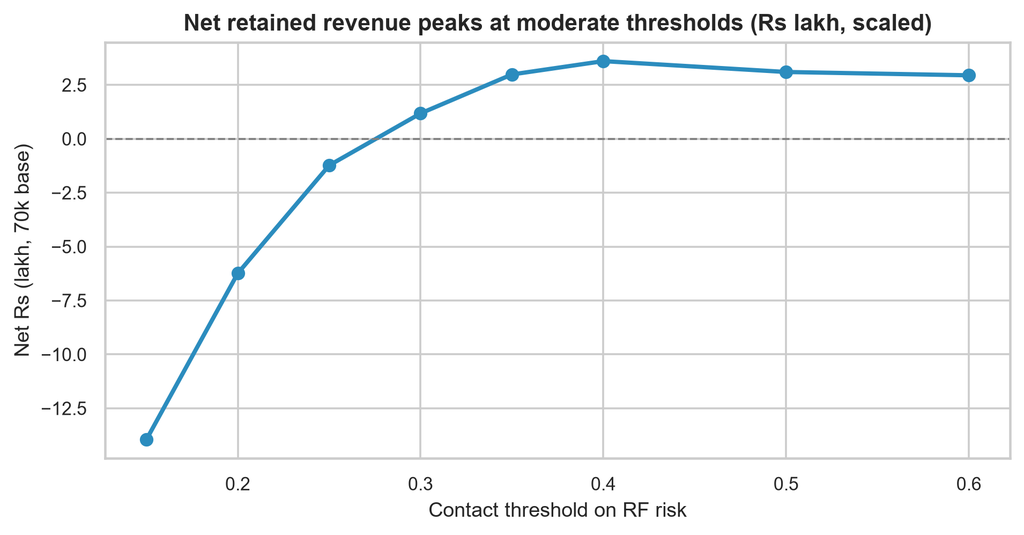

Figure 1: Scaled net retained revenue by risk threshold (Rs 150 offer, 20% success)

```python
ths, nets = [], []
for thr in [0.15, 0.2, 0.25, 0.3, 0.35, 0.4, 0.5, 0.6]:
    flag = p_te >= thr
    tp_rev = v_te.values[flag & (y_te.values == 1)].sum() * 0.20
    nets.append((tp_rev - flag.sum() * 160) * scale / 1e5)
    ths.append(thr)
fig, ax = plt.subplots(figsize=(7.5, 4.0))
ax.plot(ths, nets, marker="o", color="#2b8cbe", linewidth=2.2)
ax.axhline(0, color="grey", linestyle="--", linewidth=1)
ax.set_title("Net retained revenue peaks at moderate thresholds (Rs lakh, scaled)", fontweight="bold")
ax.set_xlabel("Contact threshold on RF risk"); ax.set_ylabel("Net Rs (lakh, 70k base)")
plt.tight_layout()
plt.show()
```